# Circular Dataset Structures

## Test the expected angle hypothesis

To test the hypothesis that the true mean direction falls in the expected direction, we can fit another model where this is explicitly stated. To inform BRMS that we do not want to estimate the mean direction, we use the notation `y~0`, which removes the intercept parameter. We can now estimate $\kappa$, *assuming* that the mean direction is 0°, using the same prior for $\kappa$ as before.

```r
#fit a model with mean at 0
model_expect = brm(formula = bf(y~0,
                              kappa~1),
                data = dt_divergence,
                family = unwrap_von_mises,
                prior = prior_divergence[2,], # just the kappa prior,
                stanvars = stan_unwrap_fun + modulo_circular_fun,
                silent = 2,
                backend = 'cmdstan'
                )

#add Leave-One-Out Cross-Validation
loo_divergence = loo(model_divergence)
loo_expected = loo(model_expect)
loo_compare(loo_divergence, loo_expected)
```

```
##                  elpd_diff se_diff
## model_divergence  0.0       0.0
## model_expect     -4.2       1.7
```

```r
#ELPD difference between two models (first minus second) and its standard error,
#calculated from pointwise ELPD in the same way as loo_compare
ElpdDiff = function(loo1, loo2, digits = 1)
{
  d = loo1$pointwise[, 'elpd_loo'] - loo2$pointwise[, 'elpd_loo']
  paste(formatC(sum(d), format = 'f', digits = digits), '±',
        formatC(sqrt(length(d)) * sd(d), format = 'f', digits = digits))
}
```

The model for a divergent mean direction has higher expected log predictive density (ELPD) than the model for the expected direction. This ELPD difference is $>2\times$ larger than its standard error, so we can state with some confidence that the hypothesis of a divergence from the expected direction is more likely than the hypothesis of alignment with the expected direction.

In this case, the expected angle model is straightforward to fit because the expected angle is 0°, which is also the default intercept for a `y~0` (no-intercept) model. If the expected direction were not 0°, we would need to adjust the data to align the expected angle with the `0` intercept, then fit both models (expected direction and divergent direction) to the adjusted data. Here is an example with the expected angle at -15°.

```r
#align the data relative to the expected angle
dt_aligned = within(dt_divergence,
                    {
                    y = y - rad(-15)  #subtract the expected angle
                    }
                    )


#we now place our expected angle at -15°, the true mean
model_true = brm(formula = bf(y ~ 0,
                            kappa~1),
               data = dt_aligned,
               family = unwrap_von_mises,
               prior = prior_divergence[2,], # just the kappa prior
               stanvars = stan_unwrap_fun + modulo_circular_fun,
               silent = 2,
               backend = 'cmdstan'
)

#this model should be compared with another fitted to the
#_same data_
model_false =  brm(formula = bf(y ~ 1,
                            kappa~1),
               data = dt_aligned,
               family = unwrap_von_mises,
               prior = prior_divergence, # the kappa and mu priors
               stanvars = stan_unwrap_fun + modulo_circular_fun,
               silent = 2,
               backend = 'cmdstan'
)

#both models converge well with rhats [1.000, 1.002]
sm_truefalse = lapply(list(true = model_true, false = model_false), summary)
#their mu estimates are very close, differing by only 2°, with overlapping CI.
round( deg(
  sm_truefalse$false$fixed['Intercept',
                                    1:4]
  ) )
```

```
##           Estimate Est.Error l-95% CI u-95% CI
## Intercept        2         4       -6       11
```

```r
#add Leave-One-Out Cross-Validation
loo_true = loo(model_true)
loo_false = loo(model_false)
loo_compare(loo_true, loo_false)
```

```
##             elpd_diff se_diff
## model_true   0.0       0.0
## model_false -0.8       0.4
```

Now the expected direction model has higher predictive power, even though both find a similar mean direction. If the divergence model had higher predictive power, but within one standard error of the expected direction model, we could not rule out the possibility that the expected direction is the true direction, though evidence would be weaker.

# Change in direction

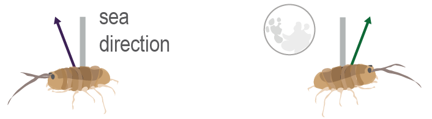

Sandhoppers (*Talitridae*) forage along beaches, following the movement of the sea to avoid drying out. Their movement is guided by celestial cues, including the moon.

If the expected direction is not known, it can be estimated from control data. This estimate can then be compared with treatment data, to determine whether the treatment alters orientation. In this example, the treatment induces a rightward turn of 30°, changing $\mu$ from 180° to 210°. Concentration is intermediate ($\kappa = 3$). The two simulated distributions have different random number seeds, to avoid producing two identical distributions of angles with a fixed shift.

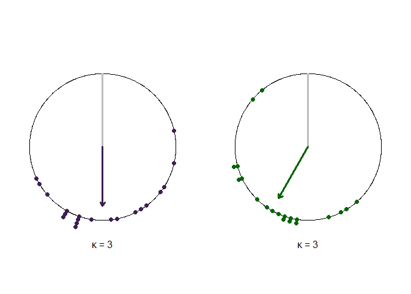

```r
par(pty = 's')
par(mar = c(0,0,0,0))
par(mfrow = c(1,2))

cd_control = DescriptCplot(m = 180,
                     k = 3,
                     ndata = ndata,
                     mvcol = col_obs,
                     sdcol = NA,
                     denscol = NA,
                     refline = c0,
                     save_sample = TRUE,
                     titleline = -1,#needs to be lower when data are South
                     seed = 1539571)#DOI Papi & Pardi

cd_treatment = DescriptCplot(m = 210,
                       k = 3,
                       ndata = ndata,
                       pcol = col_treat,
                       mvcol = col_treat,
                       sdcol = NA,
                       denscol = NA,
                       refline = c0,
                       save_sample = TRUE,
                       titleline = -1,#needs to be lower when data are South
                     seed = 0120810506) #ISBN Batschelet 1981
```